R입문 (전북대학교 2021년 2학기)

# (5주차) 10월7일

while, break, ifelse, repeat, next, switch

Oct 6, 2021 • 최규빈 • 3 min read

- 조건, 반복, 루프탈출
  - while
  - break
  - ifelse
  - switch
  - repeat
  - next
  - 요약
- 연산자
  - 산술연산자
  - 논리연산자
  - 비교연산자

## 조건, 반복, 루프탈출

### while

`-` 예제1

```r
tot = 0
i = 1
while(i<=100){
    tot=tot+i
    i = i+1
}
```

```r
tot
```

```
[1] 5050
```

`-` 예제1의 다른구현(1)

```r
tot=0
for (i in 1:100) tot = tot +i
```

```r
tot
```

```
[1] 5050
```

`-` 예제1의 다른구현(2)

```r
tot = 0
i = 1
while(TRUE){
    tot = tot+i
    i=i+1
    if (i>100) break
}
```

```r
tot
```

```
[1] 5050
```

`-` 예제1의 다른구현(3)

```r
tot = 0
i = 1
while(TRUE){
    tot = tot+i
    if (i>=100) break
    i=i+1
}
```

```r
tot
```

```
[1] 5050
```

`-` 저는 while을 싫어합니다.

`-` 어쩔수 없이 써야할때가 있어서 알고있는 것입니다.

### break

`-` 예제1

```r
for (i in 1:10){
    print(i)
    if(i==3) break
}
```

```
[1] 1
[1] 2
[1] 3
```

`-` 예제2

```r
for (i in 1:10){
    for (j in 1:10){
        print(c(i,j))
        if(j==3) break
    }
    if(i==5) break
}
```

```
[1] 1 1
[1] 1 2
[1] 1 3
[1] 2 1
[1] 2 2
[1] 2 3
[1] 3 1
[1] 3 2
[1] 3 3
[1] 4 1
[1] 4 2
[1] 4 3
[1] 5 1
[1] 5 2
[1] 5 3
```

### ifelse

`-` 예제1

```r
x= -2:2
x
```

```
[1] -2 -1  0  1  2
```

```r
ifelse(x>0,x,-x)
```

```
[1] 2 1 0 1 2
```

`-` 예제1의 다른구현

```r
length(x)
```

```
[1] 5
```

```r
y_ = x*0
y_
```

```
[1] 0 0 0 0 0
```

```r
for (i in 1:length(x)){
    if (x[i]>0) y_[i] = x[i] else
        y_[i] = -x[i]
}
```

```r
y_
```

```
[1] 2 1 0 1 2
```

`-` 예제2

```r
x= -5:5
x
```

```
 [1] -5 -4 -3 -2 -1  0  1  2  3  4  5
```

```r
y=ifelse(x<0, 0, ifelse(x>2,x,1))
```

```r
y
```

```
 [1] 0 0 0 0 0 1 1 1 3 4 5
```

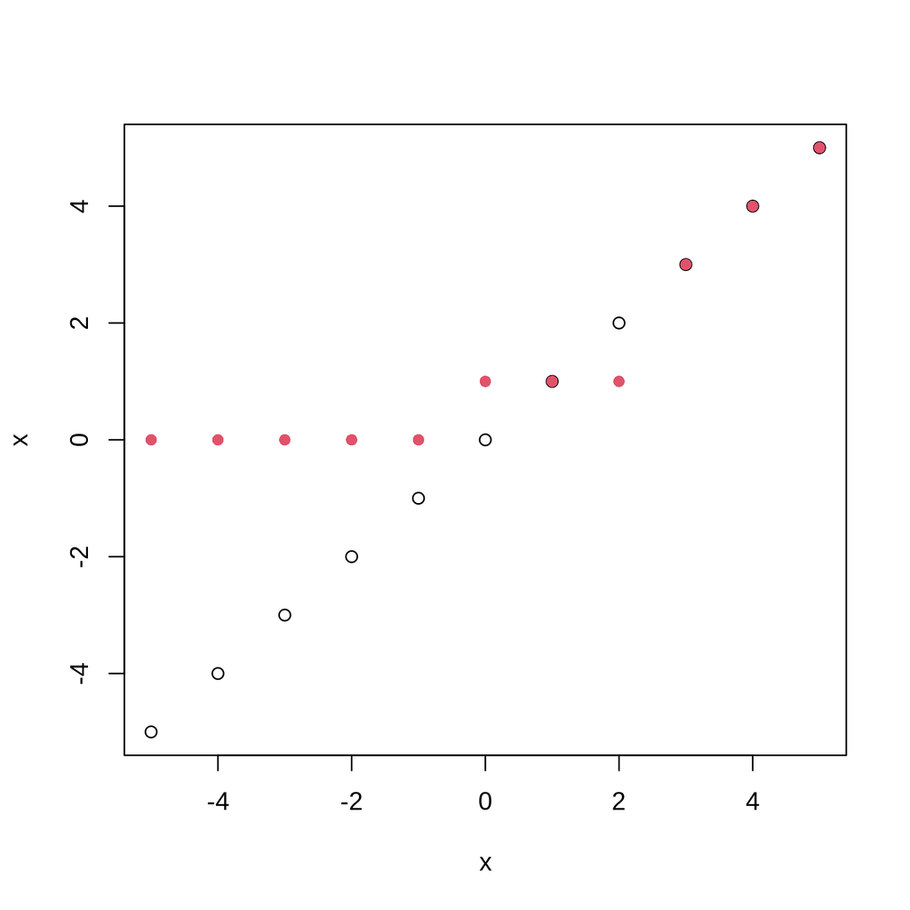

```r
plot(x,x)
points(x,y,col=2,pch=16)
```

`-` 예제2의 다른구현

```r
x= -5:5
x
```

```
 [1] -5 -4 -3 -2 -1  0  1  2  3  4  5
```

```r
y=x*0
y
```

```
 [1] 0 0 0 0 0 0 0 0 0 0 0
```

```r
n=length(x)
n
```

```
[1] 11
```

```r
for(i in 1:n){
    if(x[i]<0) y[i]=0 else
        if (x[i]>2) y[i]=x[i] else
            y[i]=1
}
```

```r
y
```

```
 [1] 0 0 0 0 0 1 1 1 3 4 5
```

`-` ifelse와 if~else는 성격이 조금 다름

- ifelse: 조건에 부합하는 새로운 벡터를 생성하는데 특화되어있음
- if~else: 조건에 따라 코드의 실행흐름을 제어하는 성격의 문법

### switch

`-` 예제1

```r
switch(1, 10,20,30)
```

```
[1] 10
```

```r
switch(2, 10,20,30)
```

```
[1] 20
```

```r
switch(3, 10,20,30)
```

```
[1] 30
```

`-` 예제2

```r
switch(1, c(1,2,3),20,c(30,40))
```

```
[1] 1 2 3
```

```r
switch(2, c(1,2,3),20,c(30,40))
```

```
[1] 20
```

```r
switch(3, c(1,2,3),20,c(30,40))
```

```
[1] 30 40
```

`-` 예제3

```r
switch('a1', a1=c(1,2,3),a2=20,a3=c(30,40))
```

```
[1] 1 2 3
```

```r
switch('a2', a1=c(1,2,3),a2=20,a3=c(30,40))
```

```
[1] 20
```

```r
switch('a3', a1=c(1,2,3),a2=20,a3=c(30,40))
```

```
[1] 30 40
```

`-` 예제4

(예비학습)

```r
x=1:10
x
```

```
 [1]  1  2  3  4  5  6  7  8  9 10
```

```r
c(
    mean(x),
    mean(x**2),
    mean((x-mean(x))**2)
)
```

```
[1]  5.50 38.50  8.25
```

```r
38.50 - 5.50**2
```

```
[1] 8.25
```

(예제시작)

```r
switch("f1",
       f1=mean(x),
       f2=mean(x**2),
       f3=mean((x-mean(x))**2)
)
```

```
[1] 5.5
```

```r
switch("f2",
       f1=mean(x),
       f2=mean(x**2),
       f3=mean((x-mean(x))**2)
)
```

```
[1] 38.5
```

```r
switch("f3",
       f1=mean(x),
       f2=mean(x**2),
       f3=mean((x-mean(x))**2)
)
```

```
[1] 8.25
```

`-` 예제5

```r
myfun<-function(x,f){
    switch(f,
       meann=mean(x),
       sqmeann=mean(x**2),
       varr=mean((x-mean(x))**2)
    )
}
```

```r
x=1:5
myfun(x,"meann")
myfun(x,"sqmeann")
myfun(x,"varr")
```

```
[1] 3
```

```
[1] 11
```

```
[1] 2
```

### repeat

`-` 예제1

```r
tot=0
i=1
repeat{
    tot=tot+i
    i=i+1
    if (i>100) break
}
```

```r
tot
```

```
[1] 5050
```

`-` 잘못된 예제1

```r
tot=0
i=1
repeat{
    tot=tot+i
    i=i+1
}
```

### next

`-` 예제1

```r
for(i in 1:5){
    if(i==3) next else
        print(i)
}
```

```
[1] 1
[1] 2
[1] 4
[1] 5
```

break와 비교

```r
for(i in 1:5){
    if(i==3) break else
        print(i)
}
```

```
[1] 1
[1] 2
```

`-` 예제2

```r
i=0
repeat{
    i=i+1
    if (i>5) break
    if (i==3) next
    print(i)
}
```

```
[1] 1
[1] 2
[1] 4
[1] 5
```

### 요약

`-` 조건: **if**, **if~else** / **ifelse**, switch

`-` 반복: **for**, while, repeat

`-` 루프탈출: break, next

## 연산자

### 산술연산자

### 논리연산자

### 비교연산자